# Risk Factor Analysis

## Outcome Variable

**Outcome Variable:** ever_stunted

## Predictor Variables

**Intervention Variable:** hdlvry

**Adjustment Set:**

unadjusted

## Stratifying Variables

The analysis was stratified on these variable(s):

- agecat
- studyid

The following strata were considered:

- agecat: 12 months, studyid: ki1000108-CMC-V-BCS-2002
- agecat: 12 months, studyid: ki1000108-IRC
- agecat: 12 months, studyid: ki1000109-EE
- agecat: 12 months, studyid: ki1000304b-SAS-FoodSuppl
- agecat: 12 months, studyid: ki1017093b-PROVIDE
- agecat: 12 months, studyid: ki1017093c-NIH-Crypto
- agecat: 12 months, studyid: ki1066203-TanzaniaChild2
- agecat: 12 months, studyid: ki1113344-GMS-Nepal
- agecat: 12 months, studyid: ki1135781-COHORTS
- agecat: 18 months, studyid: ki1000108-CMC-V-BCS-2002
- agecat: 18 months, studyid: ki1000108-IRC
- agecat: 18 months, studyid: ki1000109-EE
- agecat: 18 months, studyid: ki1000304b-SAS-FoodSuppl
- agecat: 18 months, studyid: ki1017093b-PROVIDE
- agecat: 18 months, studyid: ki1017093c-NIH-Crypto
- agecat: 18 months, studyid: ki1066203-TanzaniaChild2
- agecat: 18 months, studyid: ki1113344-GMS-Nepal
- agecat: 24 months, studyid: ki1000108-CMC-V-BCS-2002
- agecat: 24 months, studyid: ki1000108-IRC
- agecat: 24 months, studyid: ki1000109-EE
- agecat: 24 months, studyid: ki1000304b-SAS-FoodSuppl
- agecat: 24 months, studyid: ki1017093b-PROVIDE
- agecat: 24 months, studyid: ki1017093c-NIH-Crypto
- agecat: 24 months, studyid: ki1066203-TanzaniaChild2
- agecat: 24 months, studyid: ki1113344-GMS-Nepal
- agecat: 3 months, studyid: ki1000108-CMC-V-BCS-2002
- agecat: 3 months, studyid: ki1000108-IRC
- agecat: 3 months, studyid: ki1000109-EE
- agecat: 3 months, studyid: ki1017093b-PROVIDE
- agecat: 3 months, studyid: ki1017093c-NIH-Crypto
- agecat: 3 months, studyid: ki1066203-TanzaniaChild2
- agecat: 3 months, studyid: ki1113344-GMS-Nepal
- agecat: 3 months, studyid: ki1135781-COHORTS
- agecat: 6 months, studyid: ki1000108-CMC-V-BCS-2002
- agecat: 6 months, studyid: ki1000108-IRC
- agecat: 6 months, studyid: ki1000109-EE
- agecat: 6 months, studyid: ki1000304b-SAS-FoodSuppl
- agecat: 6 months, studyid: ki1017093b-PROVIDE
- agecat: 6 months, studyid: ki1017093c-NIH-Crypto
- agecat: 6 months, studyid: ki1066203-TanzaniaChild2
- agecat: 6 months, studyid: ki1113344-GMS-Nepal

### Dropped Strata

Some strata were dropped due to rare outcomes:

- agecat: 3 months, studyid: ki1000108-CMC-V-BCS-2002
- agecat: 3 months, studyid: ki1000108-IRC
- agecat: 3 months, studyid: ki1066203-TanzaniaChild2
- agecat: 6 months, studyid: ki1000108-CMC-V-BCS-2002
- agecat: 6 months, studyid: ki1000108-IRC
- agecat: 6 months, studyid: ki1066203-TanzaniaChild2
- agecat: 12 months, studyid: ki1000108-CMC-V-BCS-2002
- agecat: 12 months, studyid: ki1000108-IRC
- agecat: 12 months, studyid: ki1000304b-SAS-FoodSuppl
- agecat: 12 months, studyid: ki1066203-TanzaniaChild2
- agecat: 18 months, studyid: ki1000108-CMC-V-BCS-2002
- agecat: 18 months, studyid: ki1000108-IRC
- agecat: 18 months, studyid: ki1000304b-SAS-FoodSuppl
- agecat: 18 months, studyid: ki1066203-TanzaniaChild2
- agecat: 24 months, studyid: ki1000108-CMC-V-BCS-2002
- agecat: 24 months, studyid: ki1000108-IRC
- agecat: 24 months, studyid: ki1000109-EE
- agecat: 24 months, studyid: ki1000304b-SAS-FoodSuppl
- agecat: 24 months, studyid: ki1066203-TanzaniaChild2

## Methods Detail

We’re interested in the causal parameters $E[Y_a]$ for all values of $a \in \mathcal{A}$. These parameters represent the mean outcome if, possibly contrary to fact, we intervened to set all units to have $A=a$. Under the randomization and positivity assumptions, these are identified by the statistical parameters $\psi_a=E_W[E_{Y|A,W}(Y|A=a,W)]$. In addition, we’re interested in the mean of $Y$, $E[Y]$ under no intervention (the observed mean). We will estimate these parameters by using SuperLearner to fit the relevant likelihood factors – $E_{Y|A,W}(Y|A=a,W)$ and $p(A=a|W)$, and then updating our likelihood fit using a joint TMLE.

For unadjusted analyses ($W=\{\}$), initial likelihoods were estimated using Lrnr_glm to estimate the simple $E(Y|A)$ and Lrnr_mean to estimate $p(A)$. For adjusted analyses, a small library containing Lrnr_glmnet, Lrnr_xgboost, and Lrnr_mean was used.

Having estimated these parameters, we will then use the delta method to estimate relative risks and attributable risks relative to a prespecified baseline level of $A$.

# Results Detail

## Results Plots

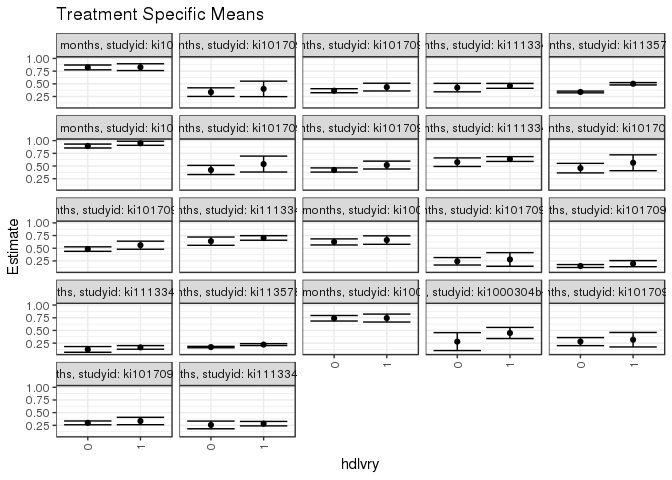

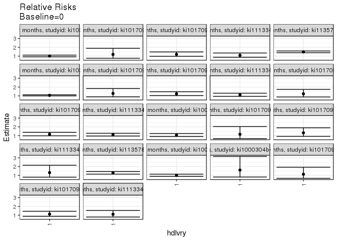

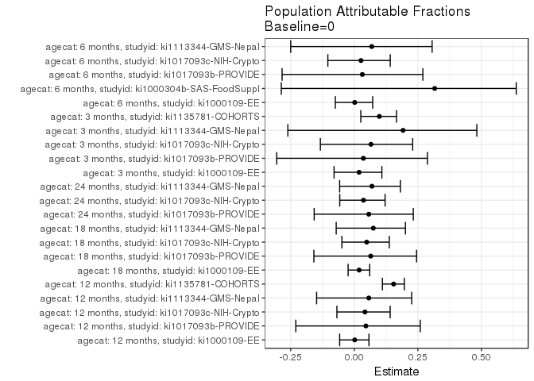

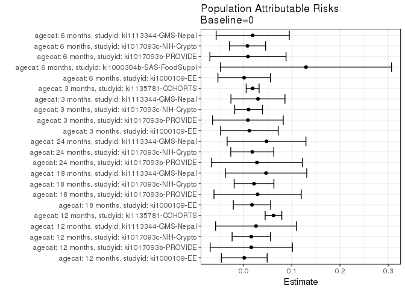

## Data Summary

| agecat | studyid | A | n | nA | nAY0 | nAY1 |
| --- | --- | --- | --- | --- | --- | --- |
| 3 months | ki1000108-CMC-V-BCS-2002 | 0 | 359 | 352 | 230 | 122 |
| 3 months | ki1000108-CMC-V-BCS-2002 | 1 | 359 | 7 | 5 | 2 |
| 3 months | ki1000108-IRC | 0 | 410 | 402 | 274 | 128 |
| 3 months | ki1000108-IRC | 1 | 410 | 8 | 6 | 2 |
| 3 months | ki1000109-EE | 0 | 377 | 253 | 95 | 158 |
| 3 months | ki1000109-EE | 1 | 377 | 124 | 42 | 82 |
| 3 months | ki1000304b-SAS-FoodSuppl | 0 | 0 | 0 | 0 | 0 |
| 3 months | ki1000304b-SAS-FoodSuppl | 1 | 0 | 0 | 0 | 0 |
| 3 months | ki1017093b-PROVIDE | 0 | 175 | 132 | 100 | 32 |
| 3 months | ki1017093b-PROVIDE | 1 | 175 | 43 | 31 | 12 |
| 3 months | ki1017093c-NIH-Crypto | 0 | 758 | 590 | 502 | 88 |
| 3 months | ki1017093c-NIH-Crypto | 1 | 758 | 168 | 135 | 33 |
| 3 months | ki1066203-TanzaniaChild2 | 0 | 571 | 561 | 508 | 53 |
| 3 months | ki1066203-TanzaniaChild2 | 1 | 571 | 10 | 8 | 2 |
| 3 months | ki1113344-GMS-Nepal | 0 | 552 | 135 | 118 | 17 |
| 3 months | ki1113344-GMS-Nepal | 1 | 552 | 417 | 348 | 69 |
| 3 months | ki1135781-COHORTS | 0 | 4962 | 3057 | 2530 | 527 |
| 3 months | ki1135781-COHORTS | 1 | 4962 | 1905 | 1483 | 422 |
| 6 months | ki1000108-CMC-V-BCS-2002 | 0 | 364 | 357 | 172 | 185 |
| 6 months | ki1000108-CMC-V-BCS-2002 | 1 | 364 | 7 | 5 | 2 |
| 6 months | ki1000108-IRC | 0 | 408 | 400 | 231 | 169 |
| 6 months | ki1000108-IRC | 1 | 408 | 8 | 4 | 4 |
| 6 months | ki1000109-EE | 0 | 371 | 250 | 65 | 185 |
| 6 months | ki1000109-EE | 1 | 371 | 121 | 31 | 90 |
| 6 months | ki1000304b-SAS-FoodSuppl | 0 | 105 | 25 | 18 | 7 |
| 6 months | ki1000304b-SAS-FoodSuppl | 1 | 105 | 80 | 44 | 36 |
| 6 months | ki1017093b-PROVIDE | 0 | 166 | 125 | 90 | 35 |
| 6 months | ki1017093b-PROVIDE | 1 | 166 | 41 | 28 | 13 |
| 6 months | ki1017093c-NIH-Crypto | 0 | 736 | 572 | 401 | 171 |
| 6 months | ki1017093c-NIH-Crypto | 1 | 736 | 164 | 109 | 55 |

[output cut: 60 more lines]

## Results Table

### Parameter: TSM

| agecat | studyid | intervention_level | baseline_level | estimate | ci_lower | ci_upper |
| --- | --- | --- | --- | --- | --- | --- |
| 3 months | ki1000109-EE | 0 | NA | 0.6245059 | 0.5647564 | 0.6842554 |
| 3 months | ki1000109-EE | 1 | NA | 0.6612903 | 0.5778792 | 0.7447014 |
| 3 months | ki1017093b-PROVIDE | 0 | NA | 0.2424242 | 0.1691069 | 0.3157416 |
| 3 months | ki1017093b-PROVIDE | 1 | NA | 0.2790698 | 0.1446196 | 0.4135199 |
| 3 months | ki1017093c-NIH-Crypto | 0 | NA | 0.1491525 | 0.1203885 | 0.1779166 |
| 3 months | ki1017093c-NIH-Crypto | 1 | NA | 0.1964286 | 0.1363119 | 0.2565452 |
| 3 months | ki1113344-GMS-Nepal | 0 | NA | 0.1259259 | 0.0699106 | 0.1819412 |
| 3 months | ki1113344-GMS-Nepal | 1 | NA | 0.1654676 | 0.1297690 | 0.2011663 |
| 3 months | ki1135781-COHORTS | 0 | NA | 0.1723912 | 0.1590002 | 0.1857823 |
| 3 months | ki1135781-COHORTS | 1 | NA | 0.2215223 | 0.2028724 | 0.2401722 |
| 6 months | ki1000109-EE | 0 | NA | 0.7400000 | 0.6855539 | 0.7944461 |
| 6 months | ki1000109-EE | 1 | NA | 0.7438017 | 0.6659159 | 0.8216874 |
| 6 months | ki1000304b-SAS-FoodSuppl | 0 | NA | 0.2800000 | 0.1031515 | 0.4568485 |
| 6 months | ki1000304b-SAS-FoodSuppl | 1 | NA | 0.4500000 | 0.3404610 | 0.5595390 |
| 6 months | ki1017093b-PROVIDE | 0 | NA | 0.2800000 | 0.2010503 | 0.3589497 |
| 6 months | ki1017093b-PROVIDE | 1 | NA | 0.3170732 | 0.1742051 | 0.4599412 |
| 6 months | ki1017093c-NIH-Crypto | 0 | NA | 0.2989510 | 0.2614089 | 0.3364932 |
| 6 months | ki1017093c-NIH-Crypto | 1 | NA | 0.3353659 | 0.2630602 | 0.4076715 |
| 6 months | ki1113344-GMS-Nepal | 0 | NA | 0.2578125 | 0.1819615 | 0.3336635 |
| 6 months | ki1113344-GMS-Nepal | 1 | NA | 0.2828784 | 0.2388634 | 0.3268935 |
| 12 months | ki1000109-EE | 0 | NA | 0.8232932 | 0.7758539 | 0.8707325 |
| 12 months | ki1000109-EE | 1 | NA | 0.8278689 | 0.7607932 | 0.8949445 |
| 12 months | ki1017093b-PROVIDE | 0 | NA | 0.3361345 | 0.2509930 | 0.4212759 |
| 12 months | ki1017093b-PROVIDE | 1 | NA | 0.4000000 | 0.2477022 | 0.5522978 |
| 12 months | ki1017093c-NIH-Crypto | 0 | NA | 0.3639576 | 0.3242927 | 0.4036225 |
| 12 months | ki1017093c-NIH-Crypto | 1 | NA | 0.4355828 | 0.3594121 | 0.5117535 |
| 12 months | ki1113344-GMS-Nepal | 0 | NA | 0.4253731 | 0.3415867 | 0.5091596 |
| 12 months | ki1113344-GMS-Nepal | 1 | NA | 0.4596577 | 0.4113142 | 0.5080012 |
| 12 months | ki1135781-COHORTS | 0 | NA | 0.3390236 | 0.3218784 | 0.3561687 |
| 12 months | ki1135781-COHORTS | 1 | NA | 0.5011001 | 0.4781140 | 0.5240862 |
| 18 months | ki1000109-EE | 0 | NA | 0.8938776 | 0.8552577 | 0.9324974 |
| 18 months | ki1000109-EE | 1 | NA | 0.9482759 | 0.9079173 | 0.9886344 |
| 18 months | ki1017093b-PROVIDE | 0 | NA | 0.4224138 | 0.3322355 | 0.5125921 |
| 18 months | ki1017093b-PROVIDE | 1 | NA | 0.5384615 | 0.3814966 | 0.6954264 |
| 18 months | ki1017093c-NIH-Crypto | 0 | NA | 0.4216216 | 0.3805092 | 0.4627340 |
| 18 months | ki1017093c-NIH-Crypto | 1 | NA | 0.5187500 | 0.4412759 | 0.5962241 |
| 18 months | ki1113344-GMS-Nepal | 0 | NA | 0.5757576 | 0.4913669 | 0.6601482 |
| 18 months | ki1113344-GMS-Nepal | 1 | NA | 0.6377171 | 0.5907450 | 0.6846892 |
| 24 months | ki1017093b-PROVIDE | 0 | NA | 0.4587156 | 0.3648532 | 0.5525780 |
| 24 months | ki1017093b-PROVIDE | 1 | NA | 0.5641026 | 0.4079464 | 0.7202587 |
| 24 months | ki1017093c-NIH-Crypto | 0 | NA | 0.4834711 | 0.4389156 | 0.5280265 |
| 24 months | ki1017093c-NIH-Crypto | 1 | NA | 0.5600000 | 0.4805003 | 0.6394997 |
| 24 months | ki1113344-GMS-Nepal | 0 | NA | 0.6390977 | 0.5573999 | 0.7207956 |
| 24 months | ki1113344-GMS-Nepal | 1 | NA | 0.7027708 | 0.6577705 | 0.7477711 |

### Parameter: E(Y)

| agecat | studyid | intervention_level | baseline_level | estimate | ci_lower | ci_upper |
| --- | --- | --- | --- | --- | --- | --- |
| 3 months | ki1000109-EE | NA | NA | 0.6366048 | 0.6348580 | 0.6383516 |
| 3 months | ki1017093b-PROVIDE | NA | NA | 0.2514286 | 0.2490845 | 0.2537727 |
| 3 months | ki1017093c-NIH-Crypto | NA | NA | 0.1596306 | 0.1582318 | 0.1610294 |
| 3 months | ki1113344-GMS-Nepal | NA | NA | 0.1557971 | 0.1543780 | 0.1572162 |
| 3 months | ki1135781-COHORTS | NA | NA | 0.1912535 | 0.1905886 | 0.1919184 |
| 6 months | ki1000109-EE | NA | NA | 0.7412399 | 0.7410583 | 0.7414215 |
| 6 months | ki1000304b-SAS-FoodSuppl | NA | NA | 0.4095238 | 0.3956081 | 0.4234395 |
| 6 months | ki1017093b-PROVIDE | NA | NA | 0.2891566 | 0.2867171 | 0.2915961 |
| 6 months | ki1017093c-NIH-Crypto | NA | NA | 0.3070652 | 0.3059697 | 0.3081607 |
| 6 months | ki1113344-GMS-Nepal | NA | NA | 0.2768362 | 0.2759234 | 0.2777489 |
| 12 months | ki1000109-EE | NA | NA | 0.8247978 | 0.8245788 | 0.8250169 |
| 12 months | ki1017093b-PROVIDE | NA | NA | 0.3522013 | 0.3478802 | 0.3565223 |
| 12 months | ki1017093c-NIH-Crypto | NA | NA | 0.3799726 | 0.3778047 | 0.3821404 |
| 12 months | ki1113344-GMS-Nepal | NA | NA | 0.4511971 | 0.4499527 | 0.4524415 |
| 12 months | ki1135781-COHORTS | NA | NA | 0.4010954 | 0.3988539 | 0.4033369 |
| 18 months | ki1000109-EE | NA | NA | 0.9113573 | 0.9087332 | 0.9139815 |
| 18 months | ki1017093b-PROVIDE | NA | NA | 0.4516129 | 0.4436595 | 0.4595663 |
| 18 months | ki1017093c-NIH-Crypto | NA | NA | 0.4433566 | 0.4403874 | 0.4463259 |
| 18 months | ki1113344-GMS-Nepal | NA | NA | 0.6224299 | 0.6201644 | 0.6246954 |
| 24 months | ki1017093b-PROVIDE | NA | NA | 0.4864865 | 0.4789813 | 0.4939916 |
| 24 months | ki1017093c-NIH-Crypto | NA | NA | 0.5015773 | 0.4990436 | 0.5041110 |
| 24 months | ki1113344-GMS-Nepal | NA | NA | 0.6867925 | 0.6844400 | 0.6891449 |

### Parameter: RR

| agecat | studyid | intervention_level | baseline_level | estimate | ci_lower | ci_upper |
| --- | --- | --- | --- | --- | --- | --- |
| 3 months | ki1000109-EE | 1 | 0 | 1.058902 | 0.9038587 | 1.240540 |
| 3 months | ki1017093b-PROVIDE | 1 | 0 | 1.151163 | 0.6517680 | 2.033202 |
| 3 months | ki1017093c-NIH-Crypto | 1 | 0 | 1.316964 | 0.9172164 | 1.890933 |
| 3 months | ki1113344-GMS-Nepal | 1 | 0 | 1.314008 | 0.8014733 | 2.154303 |
| 3 months | ki1135781-COHORTS | 1 | 0 | 1.284998 | 1.1459184 | 1.440957 |
| 6 months | ki1000109-EE | 1 | 0 | 1.005137 | 0.8843934 | 1.142366 |
| 6 months | ki1000304b-SAS-FoodSuppl | 1 | 0 | 1.607143 | 0.8167457 | 3.162439 |
| 6 months | ki1017093b-PROVIDE | 1 | 0 | 1.132404 | 0.6655167 | 1.926833 |
| 6 months | ki1017093c-NIH-Crypto | 1 | 0 | 1.121809 | 0.8740947 | 1.439723 |
| 6 months | ki1113344-GMS-Nepal | 1 | 0 | 1.097225 | 0.7865991 | 1.530517 |
| 12 months | ki1000109-EE | 1 | 0 | 1.005558 | 0.9103921 | 1.110671 |
| 12 months | ki1017093b-PROVIDE | 1 | 0 | 1.190000 | 0.7532570 | 1.879969 |
| 12 months | ki1017093c-NIH-Crypto | 1 | 0 | 1.196795 | 0.9739424 | 1.470641 |
| 12 months | ki1113344-GMS-Nepal | 1 | 0 | 1.080599 | 0.8643509 | 1.350949 |
| 12 months | ki1135781-COHORTS | 1 | 0 | 1.478069 | 1.3805189 | 1.582512 |
| 18 months | ki1000109-EE | 1 | 0 | 1.060857 | 0.9984314 | 1.127185 |
| 18 months | ki1017093b-PROVIDE | 1 | 0 | 1.274725 | 0.8881739 | 1.829512 |
| 18 months | ki1017093c-NIH-Crypto | 1 | 0 | 1.230369 | 1.0293751 | 1.470608 |
| 18 months | ki1113344-GMS-Nepal | 1 | 0 | 1.107614 | 0.9400412 | 1.305058 |
| 24 months | ki1017093b-PROVIDE | 1 | 0 | 1.229744 | 0.8715932 | 1.735063 |
| 24 months | ki1017093c-NIH-Crypto | 1 | 0 | 1.158291 | 0.9779389 | 1.371903 |
| 24 months | ki1113344-GMS-Nepal | 1 | 0 | 1.099630 | 0.9531334 | 1.268642 |

### Parameter: PAR

| agecat | studyid | intervention_level | baseline_level | estimate | ci_lower | ci_upper |
| --- | --- | --- | --- | --- | --- | --- |
| 3 months | ki1000109-EE | 0 | NA | 0.0120988 | -0.0476762 | 0.0718739 |
| 3 months | ki1017093b-PROVIDE | 0 | NA | 0.0090043 | -0.0643505 | 0.0823591 |
| 3 months | ki1017093c-NIH-Crypto | 0 | NA | 0.0104781 | -0.0183200 | 0.0392761 |
| 3 months | ki1113344-GMS-Nepal | 0 | NA | 0.0298712 | -0.0261621 | 0.0859044 |
| 3 months | ki1135781-COHORTS | 0 | NA | 0.0188623 | 0.0054548 | 0.0322698 |
| 6 months | ki1000109-EE | 0 | NA | 0.0012399 | -0.0532065 | 0.0556863 |
| 6 months | ki1000304b-SAS-FoodSuppl | 0 | NA | 0.1295238 | -0.0478713 | 0.3069189 |
| 6 months | ki1017093b-PROVIDE | 0 | NA | 0.0091566 | -0.0698307 | 0.0881440 |
| 6 months | ki1017093c-NIH-Crypto | 0 | NA | 0.0081142 | -0.0294440 | 0.0456723 |
| 6 months | ki1113344-GMS-Nepal | 0 | NA | 0.0190237 | -0.0568328 | 0.0948801 |
| 12 months | ki1000109-EE | 0 | NA | 0.0015047 | -0.0459352 | 0.0489445 |
| 12 months | ki1017093b-PROVIDE | 0 | NA | 0.0160668 | -0.0691843 | 0.1013179 |
| 12 months | ki1017093c-NIH-Crypto | 0 | NA | 0.0160150 | -0.0237091 | 0.0557391 |
| 12 months | ki1113344-GMS-Nepal | 0 | NA | 0.0258239 | -0.0579718 | 0.1096196 |
| 12 months | ki1135781-COHORTS | 0 | NA | 0.0620719 | 0.0447808 | 0.0793630 |
| 18 months | ki1000109-EE | 0 | NA | 0.0174798 | -0.0212291 | 0.0561886 |
| 18 months | ki1017093b-PROVIDE | 0 | NA | 0.0291991 | -0.0613292 | 0.1197275 |
| 18 months | ki1017093c-NIH-Crypto | 0 | NA | 0.0217350 | -0.0194845 | 0.0629545 |
| 18 months | ki1113344-GMS-Nepal | 0 | NA | 0.0466723 | -0.0377487 | 0.1310934 |
| 24 months | ki1017093b-PROVIDE | 0 | NA | 0.0277709 | -0.0663911 | 0.1219328 |
| 24 months | ki1017093c-NIH-Crypto | 0 | NA | 0.0181062 | -0.0265212 | 0.0627336 |
| 24 months | ki1113344-GMS-Nepal | 0 | NA | 0.0476947 | -0.0340370 | 0.1294265 |

### Parameter: PAF

| agecat | studyid | intervention_level | baseline_level | estimate | ci_lower | ci_upper |
| --- | --- | --- | --- | --- | --- | --- |
| 3 months | ki1000109-EE | 0 | NA | 0.0190053 | -0.0795303 | 0.1085468 |
| 3 months | ki1017093b-PROVIDE | 0 | NA | 0.0358127 | -0.3048759 | 0.2875512 |
| 3 months | ki1017093c-NIH-Crypto | 0 | NA | 0.0656394 | -0.1333252 | 0.2296742 |
| 3 months | ki1113344-GMS-Nepal | 0 | NA | 0.1917313 | -0.2611953 | 0.4820007 |
| 3 months | ki1135781-COHORTS | 0 | NA | 0.0986246 | 0.0257404 | 0.1660563 |
| 6 months | ki1000109-EE | 0 | NA | 0.0016727 | -0.0745501 | 0.0724887 |
| 6 months | ki1000304b-SAS-FoodSuppl | 0 | NA | 0.3162791 | -0.2869945 | 0.6367706 |
| 6 months | ki1017093b-PROVIDE | 0 | NA | 0.0316667 | -0.2839105 | 0.2696769 |
| 6 months | ki1017093c-NIH-Crypto | 0 | NA | 0.0264249 | -0.1039008 | 0.1413644 |
| 6 months | ki1113344-GMS-Nepal | 0 | NA | 0.0687181 | -0.2498644 | 0.3060960 |
| 12 months | ki1000109-EE | 0 | NA | 0.0018243 | -0.0573820 | 0.0577155 |
| 12 months | ki1017093b-PROVIDE | 0 | NA | 0.0456182 | -0.2298612 | 0.2593924 |
| 12 months | ki1017093c-NIH-Crypto | 0 | NA | 0.0421477 | -0.0683012 | 0.1411776 |
| 12 months | ki1113344-GMS-Nepal | 0 | NA | 0.0572342 | -0.1480371 | 0.2258026 |
| 12 months | ki1135781-COHORTS | 0 | NA | 0.1547559 | 0.1106369 | 0.1966862 |
| 18 months | ki1000109-EE | 0 | NA | 0.0191800 | -0.0242231 | 0.0607437 |
| 18 months | ki1017093b-PROVIDE | 0 | NA | 0.0646552 | -0.1587809 | 0.2450083 |
| 18 months | ki1017093c-NIH-Crypto | 0 | NA | 0.0490238 | -0.0486186 | 0.1375742 |
| 18 months | ki1113344-GMS-Nepal | 0 | NA | 0.0749841 | -0.0710871 | 0.2011345 |
| 24 months | ki1017093b-PROVIDE | 0 | NA | 0.0570846 | -0.1576846 | 0.2320107 |
| 24 months | ki1017093c-NIH-Crypto | 0 | NA | 0.0360985 | -0.0571002 | 0.1210805 |
| 24 months | ki1113344-GMS-Nepal | 0 | NA | 0.0694456 | -0.0574965 | 0.1811495 |